# 7 Flow controls, Loops

## Flow Control. Loops.

### Введение в условные операторы

Перед тем как погрузиться в детали, давайте определим, что такое условный оператор и зачем он нам нужен. В программировании, условный оператор позволяет выполнить определенный блок кода только при выполнении определенного условия. Это позволяет программе принимать решения на основе данных или внешних факторов.

### Операторы сравнения

Операторы сравнения являются ключевым инструментом для проверки условий. Они позволяют нам сравнивать значения и возвращать результаты в виде логического значения True или False. Давайте рассмотрим некоторые наиболее часто используемые операторы сравнения, такие как равно (==), не равно (!=), больше (>), меньше (<), больше или равно (>=), меньше или равно (<=).

```python
x = 5
y = 10

print(x == y)  # False
print(x < y)   # True
print(x >= y)  # False
```

```
False
True
False
```

### Инструкция if

Оператор if позволяет нам выполнить определенный блок кода, если условие истинно. Он имеет следующий синтаксис:

```
if условие:
    # выполняемые действия, если условие истинно
```

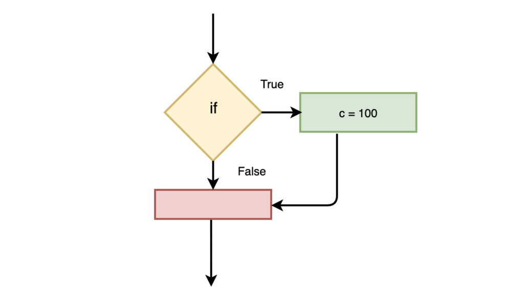

```python
x = 1

if x > 0:
    print("Число положительное")

print("Конец")
```

```
Число положительное
Конец
```

```python
a = 10
c = 0

if a == 10:
    c = 100

print(c)
```

```
100
```

### Проверка истинности в Python

- Любое число, не равное 0, или непустой объект - истина.
- Числа, равные 0, пустые объекты и значение None - ложь
- Операции сравнения применяются к структурам данных рекурсивно
- Операции сравнения возвращают True или False
- Логические операторы and и or возвращают истинный или ложный объект-операнд

### if-else

Оператор else позволяет задать блок кода, который выполнится, если условие оператора if не истинно. Оператор elif (сокращение от "else if") используется для проверки дополнительных условий, если предыдущие условия были ложными. Давайте рассмотрим пример:

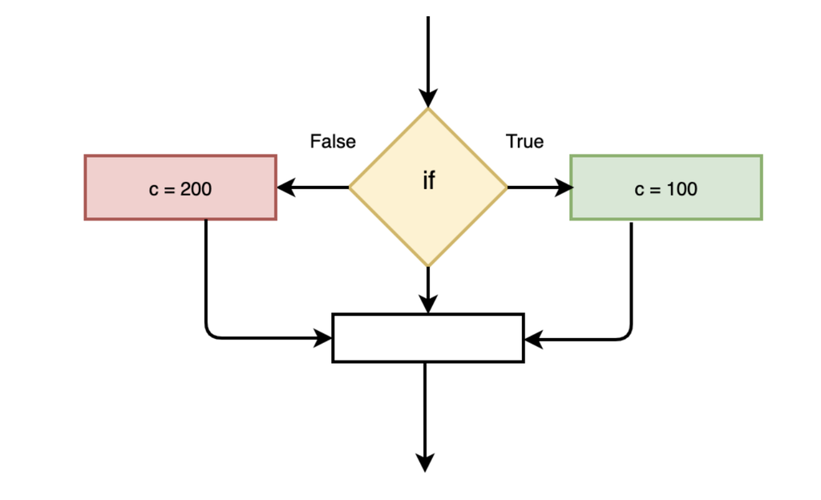

```python
x = -1

if x > 0:
    print("Число положительное")
elif x < 0:
    print("Число отрицательное")
else:
    print("Число равно нулю")
```

В языке Python такого же эффекта можно добиться при помощи выражения – благодаря тому, что функция bool преобразует X в соответствующее целое число 1 или 0, которое затем используется для выбора требуемого значения из списка:

`A = [“Z”, “Y”][bool(“X”)]`

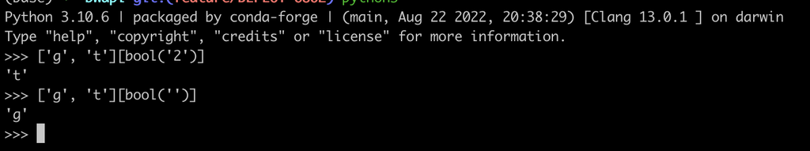

### if-elif-else

Иногда нам нужно выполнить более сложные проверки или проверить несколько условий одновременно. Для этого мы можем использовать вложенные условия, то есть условные операторы внутри других условных операторов.

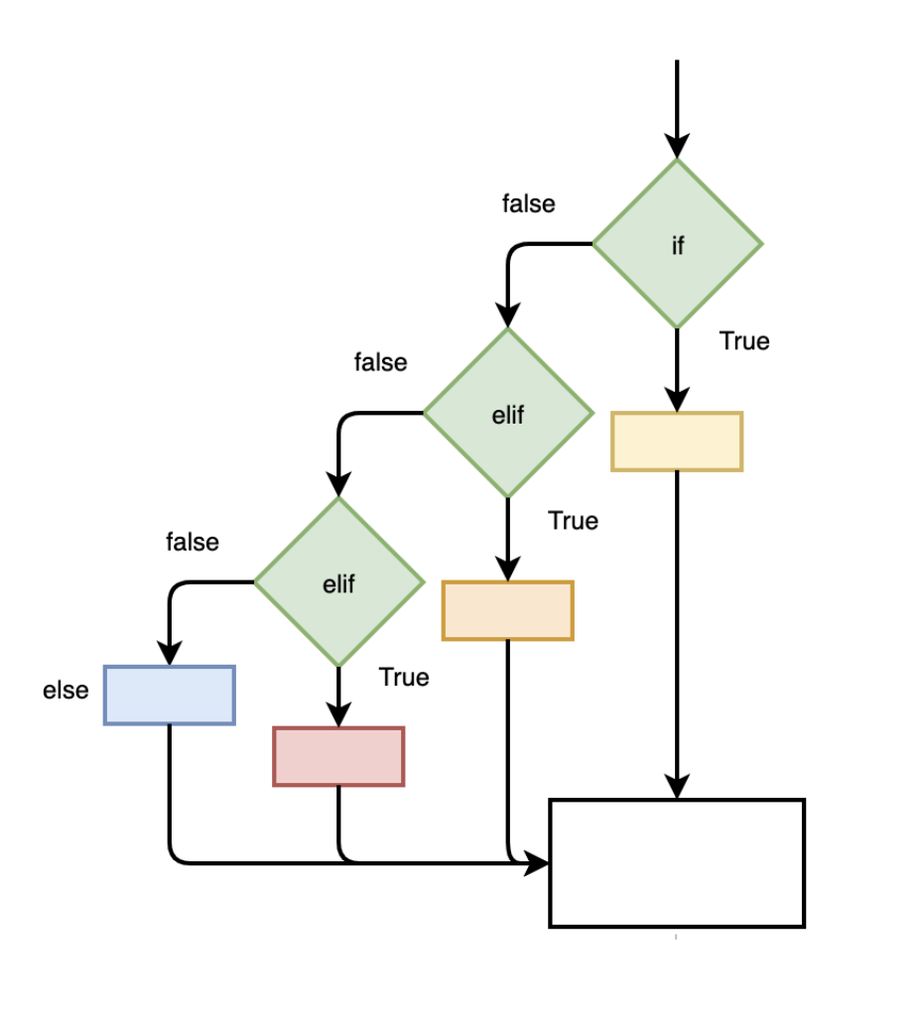

```python
x = 6
y = 10

if x > 0:
    if y > 0:
        print("Оба числа положительные")
    else:
        print("Первое число положительное, второе число отрицательное")
else:
    print("Первое число отрицательное")
```

[output not shown]

```python
a = 100
c = 0

if a < 10:
    c = 100
elif a == 100:
    c = 200
else:
    c = 300

print(c)
```

[output not shown]

### One line if

```python
var_name = 100

if var_name == 100: print(f"Velue of expression is {var_name}")
print("Good bye!")
```

```
Velue of expression is 100
Good bye!
```

```python
a = 10
print("More than 0" if a > 0 else "Less than 0")
```

```
More than 0
```

### Циклы

Циклы - это инструмент, который позволяет выполнять определенные действия множество раз. Они особенно полезны, когда нам нужно повторять один и тот же код или операции несколько раз. https://pythontutor.com/render.html#mode=edit

В Python существует два основных типа циклов:

- for
- while.

#### Цикл for

Цикл for позволяет перебирать элементы в заданном диапазоне или в коллекции. Он выполняет указанный блок кода для каждого элемента в заданной последовательности.

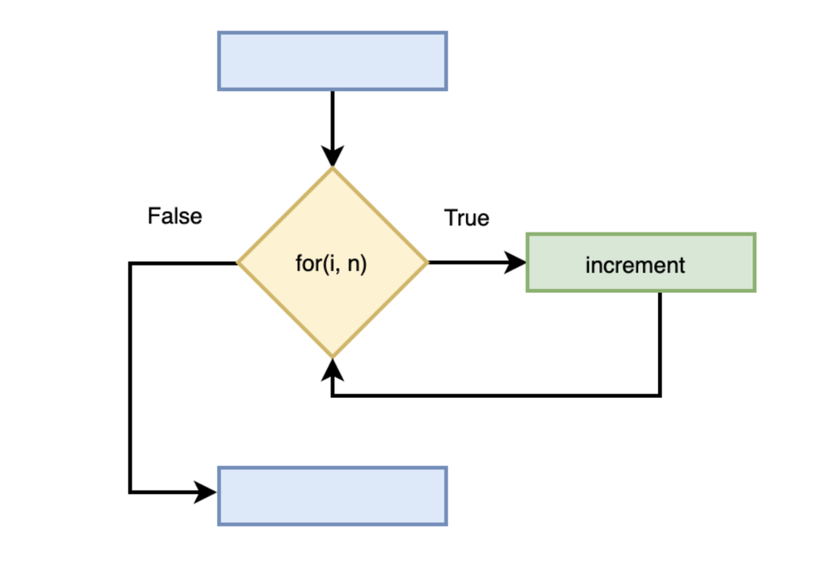

```python
for i in range(5):
    print(i)
```

[output not shown]

В этом примере мы используем цикл for для вывода чисел от 0 до 4. Функция range(5) создает последовательность чисел от 0 до 4, и каждое число передается в переменную i, которую мы используем внутри цикла.

```python
for (a, b) in [(1, 2), (3, 4), (5, 6)]:
    print(a, b)

for (a, *b, c) in [(1, 2, 3, 4), (5, 6, 7, 8)]:
    print(a, b, c)
```

```
1 2
3 4
5 6
1 [2, 3] 4
5 [6, 7] 8
```

### Вложенные циклы for

```python
l = [[1, 2, 3, 4], [5, 6, 7, 8], [9, 0, 1, 2]]

for i in l:
    for y in i:
        print(y, end=":")
```

```
1:2:3:4:5:6:7:8:9:0:1:2:
```

### Цикл while

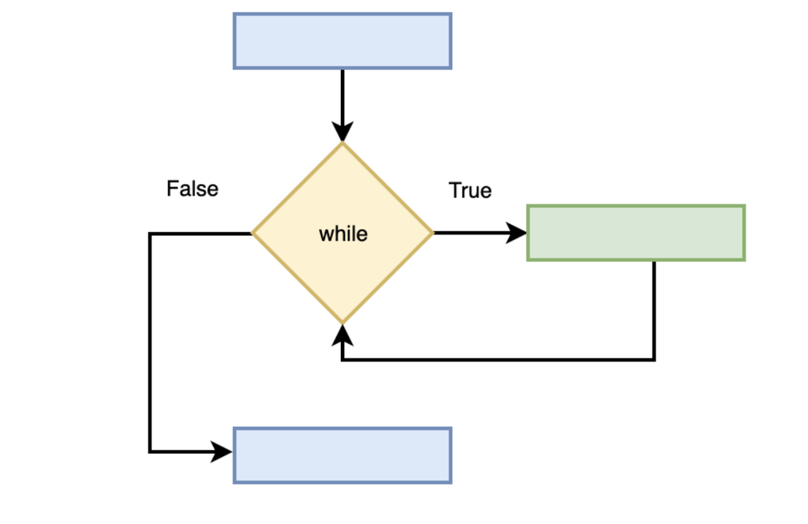

```python
count = 0

while count < 5:
    print(count)
    count += 1
```

```
0
1
2
3
4
```

В этом примере мы используем цикл while для вывода чисел от 0 до 4. Переменная count инициализируется значением 0, и пока count меньше 5, код внутри цикла выполняется. После каждой итерации мы увеличиваем count на 1, чтобы в конечном итоге завершить цикл.

Циклы позволяют автоматизировать повторяющиеся задачи и обрабатывать большие объемы данных. Они особенно полезны при работе с коллекциями, такими как списки или словари.

### else в циклах

```python
# while
i = 10
while i > 0:
    print(i)
    i -= 1
else: # i > 0 == Flase
    print("End")


# for
for i in range(0, 10):
    print(i)
else: # end of iteration
    print("End")
```

```
10
9
8
7
6
5
4
3
2
1
End
0
1
2
3
4
5
6
7
8
9
End
```

### Оператор break

Оператор break - это инструкция, которая позволяет прервать выполнение цикла досрочно. Когда оператор break достигается внутри цикла, выполнение цикла немедленно прекращается, и управление передается к коду, следующему после цикла.

```python
for i in range(1, 11):
    if i == 5:
        break
    print(i)
```

```
1
2
3
4
```

В этом примере мы используем цикл for для итерации от 1 до 10. Но при условии, что i равно 5, мы вставляем оператор break, который прерывает выполнение цикла. В результате на экране будут выведены числа 1, 2, 3, и 4. Как только достигнуто условие i == 5, цикл прекращается и код, следующий за циклом, начинает выполняться.

Оператор break может быть полезен, когда необходимо прервать цикл, когда выполняется определенное условие или достигается определенный результат. Он позволяет сэкономить время и ресурсы, прерывая выполнение цикла, когда это необходимо.

Важно помнить, что оператор break прерывает только ближайший внутренний цикл, в котором он находится. Если в программе есть вложенные циклы, break остановит только самый внутренний цикл.

### Оператор continue

Оператор continue - это инструкция, которая прерывает текущую итерацию цикла и переходит к следующей итерации. Когда оператор continue достигается внутри цикла, оставшаяся часть кода внутри цикла не выполняется, и управление возвращается в начало цикла для следующей итерации.

```python
for i in range(1, 11):
    if i == 5:
        continue
    print(i)
```

В этом примере мы используем цикл for для итерации от 1 до 10. Но при условии, что i равно 5, мы вставляем оператор continue, который пропускает оставшуюся часть кода внутри цикла и переходит к следующей итерации. В результате на экране будут выведены числа от 1 до 4 и от 6 до 10.

Оператор continue может быть полезен, когда нужно пропустить определенные итерации цикла на основе условия. Например, можно использовать его для пропуска обработки определенных значений или выполнения определенных операций для определенных условий.

Важно помнить, что оператор continue прерывает только текущую итерацию цикла и переходит к следующей итерации. Весь оставшийся код внутри цикла после оператора continue не выполняется. Если в программе есть вложенные циклы, continue пропустит только текущую итерацию внутреннего цикла, но продолжит выполнение остальных итераций внешнего цикла.

### Pattern matching(Python >=3.10)

Механизм для проверки данных, их распаковки и управления потоком выполнения. Сопоставление выражения с некоторым шаблономб в каком-то смысле похоже на if/else/elif конструкцию:

```python
status = response.status
if status == 200:
    do_something(response.data)  # OK
elif status == 301 or status == 302:
    retry(response.location)  # Redirect
elif status == 401:
    retry(auth=get_credentials())  # Login first
elif status == 426:
    sleep(DELAY)  # Server is swamped, try after a bit
    retry()
else:
    raise RequestError("we couldn't get the data")
```

```python
match response.status:
    case 200:
        do_something(response.data)  # OK
    case 301 | 302:
        retry(response.location)  # Redirect
    case 401:
        retry(auth=get_credentials())  # Login first
    case 426:
        sleep(DELAY)  # Server is swamped, try after a bit
        retry()
    case _:
        raise RequestError("we couldn't get the data")
```

### Ввод данных с клавиатуры

Для этого в Python есть функция input(). Когда вызывается эта функция, программа останавливает свое выполнение и ждет, когда пользователь введет текст. После этого, когда он нажмет Enter, функция input() заберет введенный текст и передаст его программе.

```python
# answer = input();
# print(answer)

name = input("Enter your name: ")
print(f"Hello {name}")
```

[output not shown]

### next()

```python
fruits = ['apple', 'orange', 'pear']
iterator = fruits.__iter__()

x = next(iterator)
x = next(iterator)

print(next(iterator))
# print(next(iterator))
print(x)
```

```
pear
orange
```

Но, зачем нам это необходимо, если можно просто использовать `for` или `while`? Это может быть полезно, когда мы работаем с генераторами и хотим контролировать процесс итерациию Например содздать определенное кол-во элеметнов, а потом остановиться:

```python
def generate_number():
    n = 1
    while True:
        yield n
        n += 1

generator = generate_number()
print(generator)

first = next(generator)
second = next(generator)
third = next(generator)

print(first, second)
```

[output not shown]